```python
import pandas as pd
import numpy as np
import matplotlib.pyplot as plt
import seaborn as sns
import scipy.stats as stats
from scipy.stats import ttest_1samp
from statsmodels.stats.power import tt_ind_solve_power
```

# T test

A T test is inferntial statistics which is used to determine if there is a significant difference between the mean of two groups which may be related in certain features

T test has 2 types : 1) One sampled t test 2) Two sampled t test

```
  t = ( sample mean - population mean ) / standard error
```

```python
ages = [10,20,30,35,40,45,50,55,18,28,30,43,18,30,28,14,24,16,17,32,35,26,20,19,34,55,23,22,21,30]      # this is population data
```

```python
ages_mean = np.mean(ages)
print(ages_mean)
```

```
28.933333333333334
```

```python
len(ages)
```

```
30
```

```python
# Lets take sample
sample_size = 10                                      # make sample of size 10 from population
age_sample = np.random.choice(ages,sample_size)
age_sample
```

```
array([45, 35, 23, 45, 18, 28, 22, 16, 10, 28])
```

```python
from scipy.stats import ttest_1samp
```

```python
ttest,pvalue = ttest_1samp(age_sample,30)
```

```python
print(pvalue)
```

```
0.4408675419860427
```

```python
if pvalue < 0.05:        # this is for 95%  if quetion given for 90% so here we take 0.1
    print("we are rejecting null hypothesis")
else:
    print("we are accepting null hypothesis")
```

```
we are accepting null hypothesis
```

```python
df = pd.read_excel("C:/FDS data sets/result.xlsx")
df
```

|  | Roll No | Name | sub1 | sub2 | sub3 | Total | Result |
| --- | --- | --- | --- | --- | --- | --- | --- |
| 0 | 101 | Akash | 45 | 45 | 45 | 135 | p |
| 1 | 102 | Manoj | 35 | 45 | 42 | 122 | p |
| 2 | 103 | Mrunal | 29 | 26 | 30 | 85 | p |
| 3 | 104 | Saurabh | 38 | 35 | 29 | 102 | p |
| 4 | 105 | Ashish | 41 | 40 | 34 | 115 | p |
| 5 | 106 | Sudhir | 46 | 62 | 41 | 149 | p |
| 6 | 107 | Ria | 29 | 48 | 27 | 104 | p |
| 7 | 108 | Prathana | 43 | 33 | 33 | 109 | p |
| 8 | 109 | Mihika | 37 | 30 | 38 | 105 | p |
| 9 | 110 | Shaurya | 33 | 31 | 41 | 105 | p |

```python
df.describe()
```

|  | Roll No | sub1 | sub2 | sub3 | Total |
| --- | --- | --- | --- | --- | --- |
| count | 10.00000 | 10.000000 | 10.000000 | 10.000000 | 10.000000 |
| mean | 105.50000 | 37.600000 | 39.500000 | 36.000000 | 113.100000 |
| std | 3.02765 | 6.168018 | 10.783217 | 6.236096 | 18.241893 |
| min | 101.00000 | 29.000000 | 26.000000 | 27.000000 | 85.000000 |
| 25% | 103.25000 | 33.500000 | 31.500000 | 30.750000 | 104.250000 |
| 50% | 105.50000 | 37.500000 | 37.500000 | 36.000000 | 107.000000 |
| 75% | 107.75000 | 42.500000 | 45.000000 | 41.000000 | 120.250000 |
| max | 110.00000 | 46.000000 | 62.000000 | 45.000000 | 149.000000 |

Hypothesis testing or significance testing hypothesis testing is a set of formal procedures used by statisticians to either accept or reject statistical hypothesis. statistical hypothesis are of two types :

1) check if total mean value of marks is not more than 113

Null hypothesis will be

Ho : mu <= 113

Alternative hypothesis will be

Ha : mu > 113

```python
# null hyp          # this is one tailed t test  # lect 30 nov
Ho = "mu <=113"

#alt hyp
Ha = "mu > 113"

# aplha
al = 0.05

# mu -> mean
mu = 113

# tail test
tt = 1

# data
marks = df['Total'].values
print("Ho: ",Ho)
print("Ha: ",Ha)
print("al: ",al)
print("mu: ",mu)
marks
```

```
Ho:  mu <=113
Ha:  mu > 113
al:  0.05
mu:  113
```

```
array([135, 122,  85, 102, 115, 149, 104, 109, 105, 105], dtype=int64)
```

```python
ts , pv = ttest_1samp(marks,mu)    # 1st parameter is about sample data and 2nd parameter is about population data
print("t-stat ",ts)
print("p-value ",pv)
t2pv = pv                     # when we have 2 tailed that means we have aplha by 2  so p value is same as 2 tailed
t1pv = pv*2                   # when we have 1 tailed that mean we have alpha so here we multiply by 2
print("1t pv ",t1pv)
print("2t pv ",t2pv)
```

```
t-stat  0.01733524930528476
p-value  0.9865473848679749
1t pv  1.9730947697359498
2t pv  0.9865473848679749
```

```python
if tt == 1:
    if t1pv < al:
        print("Null Hypothesis is Rejected")
        print("conclusion: ",Ha)
    else:
        print("Null Hypothesis Not Rejected")
        print("conclusion: ",Ho)
else:
    if t2pv < al/2:
        print("Null Hypothesis is Rejected")
        print("conclusion: ",Ha)
    else:
        print("Null Hypothesis Not Rejected")
        print("conclusion: ",Ho)
```

```
Null Hypothesis Not Rejected
conclusion:  mu <=113
```

Two way hypothesis

```python
#null hyp     # this is two tailed because here we have = and !=

Ho = "mu = 113"

#alt hyp
Ha = "mu !=113"

#alpha
al = 0.05

# mu
mu = 113

# tail test
tt = 2

# data
marks = df['Total'].values
print("Ho: ",Ho)
print("Ha: ",Ha)
print("al: ",al)
print("mu: ",mu)
marks
```

```
Ho:  mu = 113
Ha:  mu !=113
al:  0.05
mu:  113
```

```
array([135, 122,  85, 102, 115, 149, 104, 109, 105, 105], dtype=int64)
```

```python
ts , pv = ttest_1samp(marks,mu)
print("t-stat ",ts)
print("p-value ",pv)
t2pv = pv
t1pv = pv*2
print("1t pv ",t1pv)
print("2t pv ",t2pv)
```

```
t-stat  0.01733524930528476
p-value  0.9865473848679749
1t pv  1.9730947697359498
2t pv  0.9865473848679749
```

```python
if tt == 1:
    if t1pv < al:
        print("Null Hypothesis is Rejected")
        print("conclusion: ",Ha)
    else:
        print("Null Hypothesis Not Rejected")
        print("conclusion: ",Ho)
else:
    if t2pv < al/2:
        print("Null Hypothesis is Rejected")
        print("conclusion: ",Ha)
    else:
        print("Null Hypothesis Not Rejected")
        print("conclusion: ",Ho)
```

```
Null Hypothesis Not Rejected
conclusion:  mu = 113
```

# AB Testing

AB testing is essentially an experiment where two or more variants of a page are shown to users at random, and statistical analysis is used to determine which variation performs better for a given conversion goal.

```python
subj1 = np.array([45,36,29,40,46,37,43,39,28,33])
subj2 = np.array([40,20,30,35,29,43,40,39,28,31])
```

```python
print(subj1)
print(subj2)
```

```
[45 36 29 40 46 37 43 39 28 33]
[40 20 30 35 29 43 40 39 28 31]
```

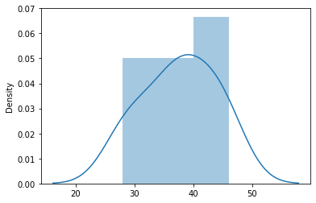

```python
sns.distplot(subj1)
```

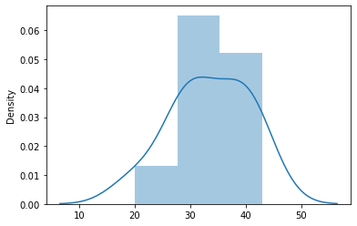

```python
sns.distplot(subj2)
```

The two hypothesis for this particular two sample t test are as follows :

Ho : μ1 = μ2 (the two population means are equal)

Ha : μ1 ≠ μ2 (the two population means are not equal)

```python
t_stat , p_val = stats.ttest_ind(subj1,subj2)
t_stat , p_val
```

```
(1.365908039538178, 0.18879292981719703)
```

```python
# perform two sample t-test with equal variance

stats.ttest_ind(subj1,subj2,equal_var=True)
```

```
Ttest_indResult(statistic=1.365908039538178, pvalue=0.18879292981719703)
```

The t test is 1.3659 and the corresponding two - sided p-value is 0.1887. because the p-value of iur test (0.1887) is greater than alpha = 0.05, we fail to reject the null hypothesis of the test

we do not have sufficient evidence to say that the mean marks of subj1 and subj2 between the two is different.